# Ejercicio de Pronóstico

Importaciones de EEUU de autos mexicanos

Author

Gibrán Leonardo Chávez González

Published

September 11, 2026

Importamos las librerías con las que vamos a trabajar:

```r
library(tidyverse)
library(fpp3)
```

```r
imports <- tidyquant::tq_get(
    x = 'MAUINSA',
    get = 'economic.data',
    from = '1993-01-01',
    to = '2025-10-01'
) |>
    mutate(
        date = yearmonth(date)
    ) |>
        as_tsibble(index = date)
```

Vemos cuál es la estructura de la serie de tiempo:

```r
imports
```

```
# A tsibble: 394 x 3 [1M]
   symbol       date price
   <chr>       <mth> <dbl>
 1 MAUINSA 1993 ene.   7.5
 2 MAUINSA 1993 feb.  18.9
 3 MAUINSA 1993 mar.  10.7
 4 MAUINSA 1993 abr.  19.9
 5 MAUINSA 1993 may.  19.7
 6 MAUINSA 1993 jun.  25.7
 7 MAUINSA 1993 jul.  15
 8 MAUINSA 1993 ago.  13.1
 9 MAUINSA 1993 sep.  24.6
10 MAUINSA 1993 oct.  23.9
# ℹ 384 more rows
```

Ahora, graficamos la serie de tiempo:

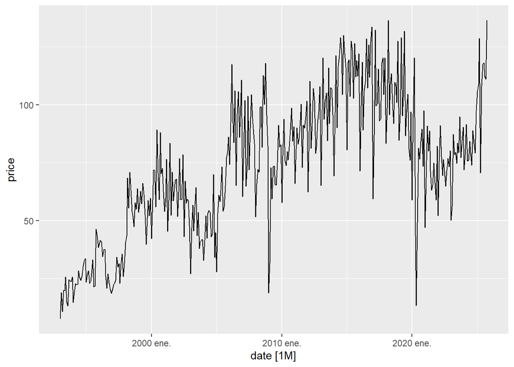

```r
imports |>
    autoplot(price)
```

Queremos pronosticar los próximos 14 meses, por lo tanto, haremos un train-test split donde se dejarán los últimos 14 meses para testear el modelo. Para esto, definimos la variable de `train` y de `test`, además del horizonte:

```r
h <- 14

df_train <- imports |>
    slice_head(n = nrow(imports) - h)

df_test <- imports |>
    slice_tail(n = h)
```

Ahora, volvemos a graficar, pero esta vez únicamente el conjunto de entrenamiento:

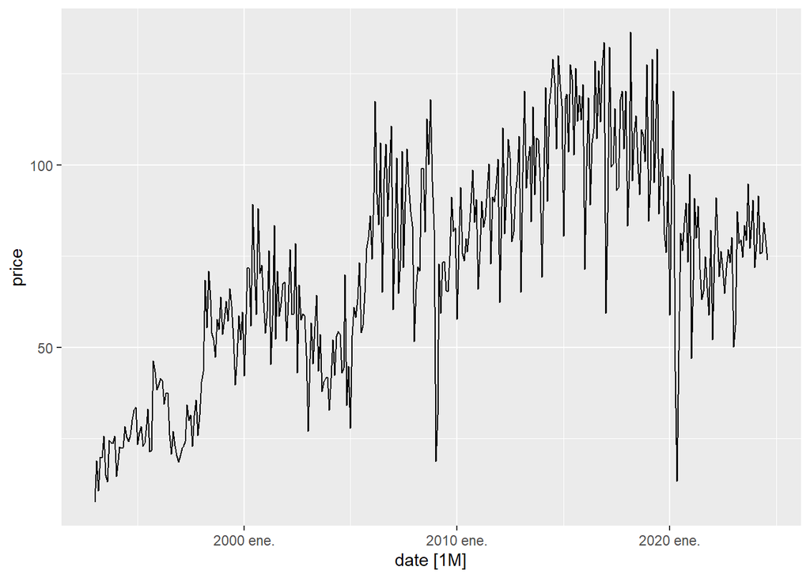

```r
df_train |>
    autoplot(price)
```

```r
componentes_train <- df_train |>
    model(
        stl = STL(
            price ~ trend(window = 25) + season(window = 'periodic'),
            robust = TRUE
        )
    ) |>
        components()
```

Ahora graficamos cada componente:

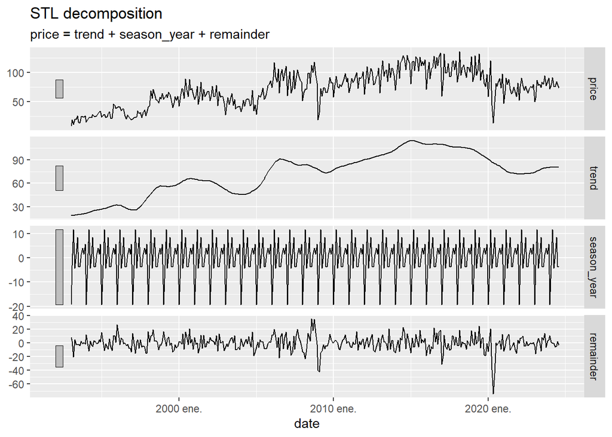

```r
componentes_train |>
    autoplot()
```

Ya vemos más claramente de lo que hablamos, la serie tiene una estacionalidad marcada y un componente de tendencia que parece ser creciente.

Ahora procederemos a estimar con 4 modelos, los cuales son:

```
- Mean
- Naive
- Seasonal Naive
- Drift
```

## Sin transformación

```r
descomposition <- decomposition_model(
    STL(
        price ~ trend(window = 25) + season(window = "periodic"),
        robust = TRUE
    ),
    RW(season_adjust ~ drift()),
    SNAIVE(season_year)
)

df_fit <- df_train |>
    model(
        media = MEAN(price),
        naive = NAIVE(price),
        snaive = SNAIVE(price),
        drift = RW(price ~ drift()),
        desc = descomposition
    )
```

La serie pronosticada se obtiene mediante:

$$\widehat{y}_{t+h\mid t}
=
\widehat{T}_{t+h\mid t}
+
\widehat{S}_{t+h\mid t}
+
\widehat{R}_{t+h\mid t},$$

donde:

- $\widehat{T}_{t+h\mid t}$ es la tendencia pronosticada;
- $\widehat{S}_{t+h\mid t}$ es la estacionalidad pronosticada;
- $\widehat{R}_{t+h\mid t}$ es el residuo pronosticado.

Ahora, vemos los residuos en cada modelo:

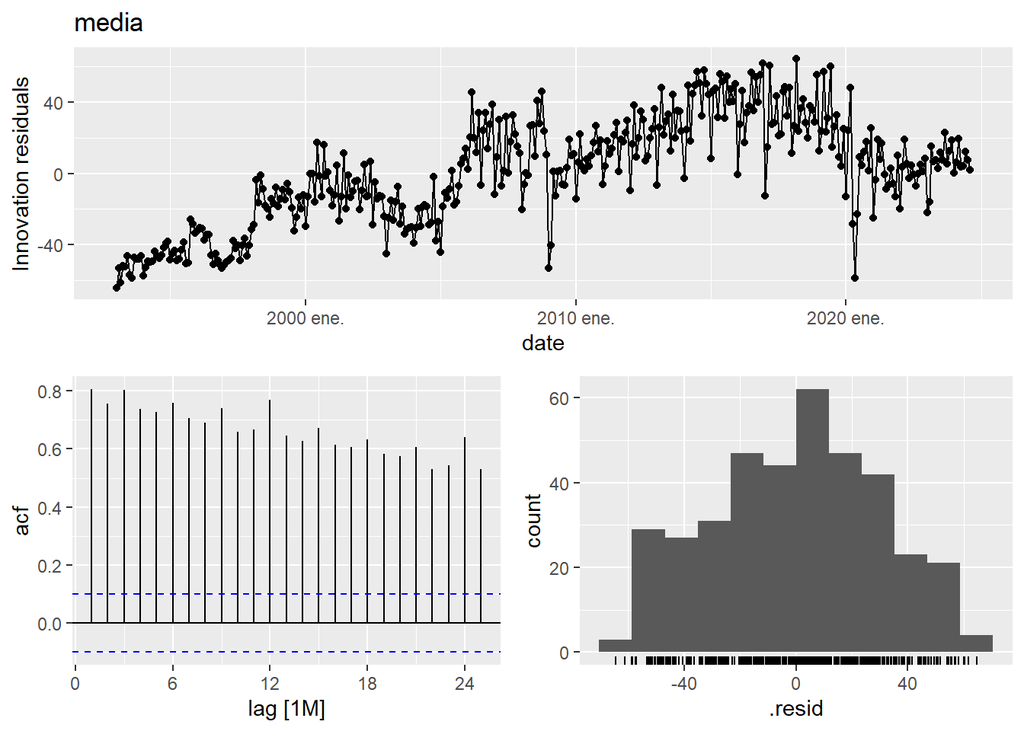

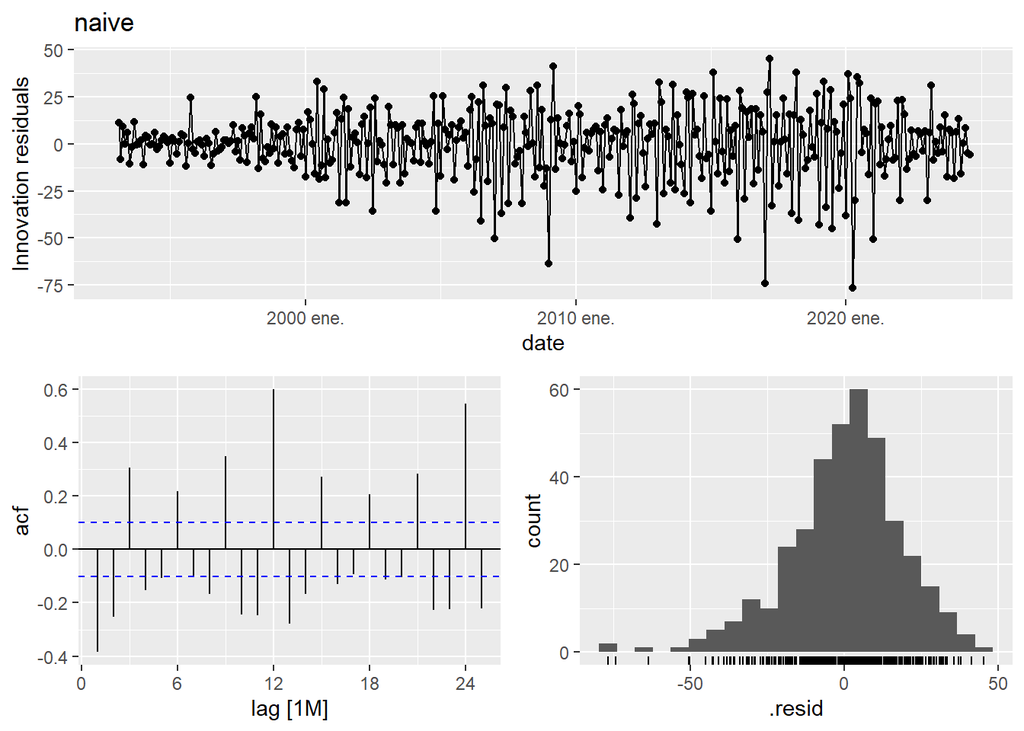

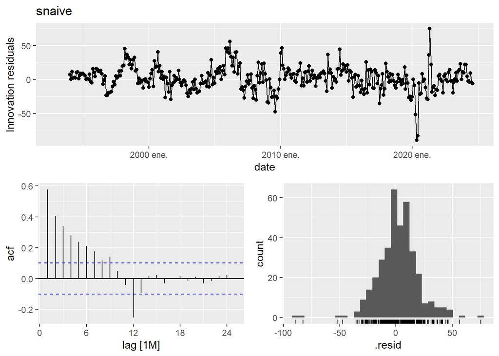

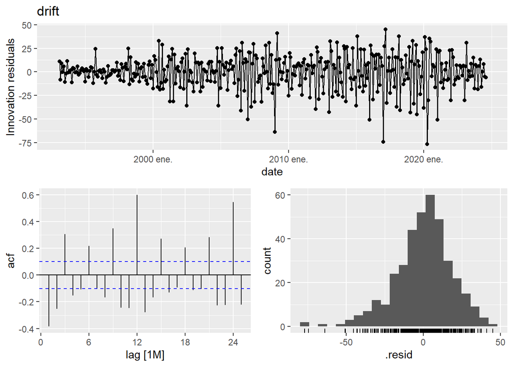

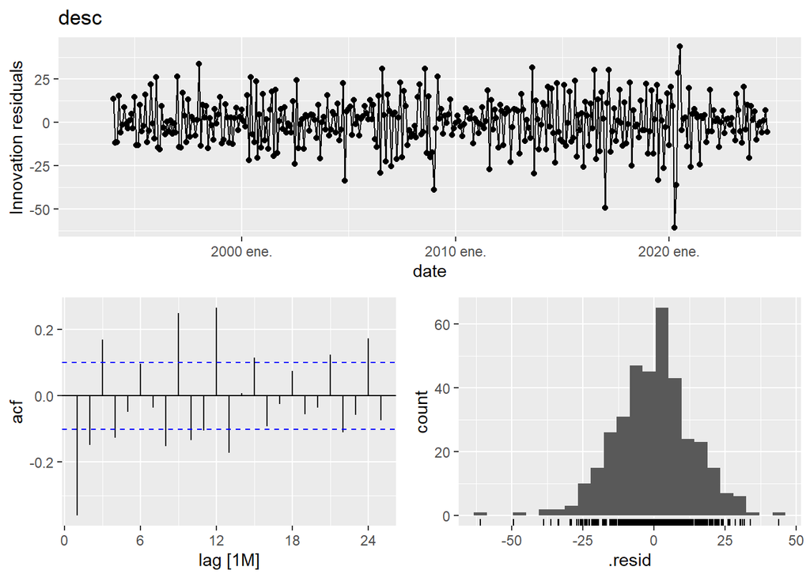

```r
for (model in colnames(df_fit)) {
    residuos <- df_fit |>
        select(all_of(model)) |>
        gg_tsresiduals() + labs(title = model)

    print(residuos)
}
```

Aplicamos además el test de Ljung-Box sobre los residuos de innovación para contrastar formalmente la hipótesis de ruido blanco:

```r
df_fit |>
    augment() |>
    features(.innov, ljung_box, lag = 24)
```

```
# A tibble: 5 × 3
  .model lb_stat lb_pvalue
  <chr>    <dbl>     <dbl>
1 desc      195.         0
2 drift     699.         0
3 media    4303.         0
4 naive     699.         0
5 snaive    351.         0
```

Ahora, hacemos el pronóstico y evaluamos:

```r
df_fc <- df_fit |>
    forecast(h = nrow(df_test))

df_fc |>
  accuracy(df_test)
```

```
# A tibble: 5 × 10
  .model .type    ME  RMSE   MAE   MPE  MAPE  MASE RMSSE  ACF1
  <chr>  <chr> <dbl> <dbl> <dbl> <dbl> <dbl> <dbl> <dbl> <dbl>
1 desc   Test   25.7  31.2  26.3  22.2  23.1   NaN   NaN 0.309
2 drift  Test   29.5  34.4  30.2  25.8  26.8   NaN   NaN 0.143
3 media  Test   32.8  37.5  33.0  29.0  29.3   NaN   NaN 0.173
4 naive  Test   30.8  35.8  31.3  27.0  27.7   NaN   NaN 0.173
5 snaive Test   22.5  29.8  24.9  18.9  21.9   NaN   NaN 0.172
```

Después, graficamos para ver como es nuestro pronóstico en comparación con los datos de test:

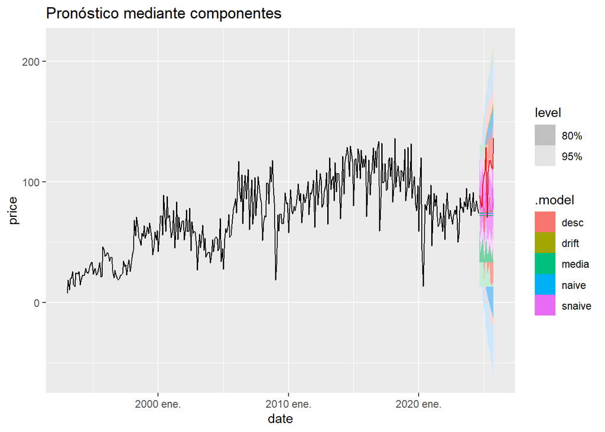

```r
df_fc |>
    autoplot(df_train) +
    autolayer(
        df_test,
        price,
        colour = 'red'
    ) + labs(title = 'Pronóstico mediante componentes')
```

En niveles, ningún modelo pasa el test de Ljung-Box (p-values muy pequeños): los residuos del modelo de descomposición conservan autocorrelación significativa en el rezago 1 y algo de estructura estacional. El mejor *benchmark* individual por error es `snaive`, pero su MAPE ronda el 22%.

## Repetición con transformación logarítmica

Repitamos el proceso, pero haciendo una transformación logarítmica, para ver si podemos mejorar. Primero ploteamos la serie, después modelamos y vemos residuos:

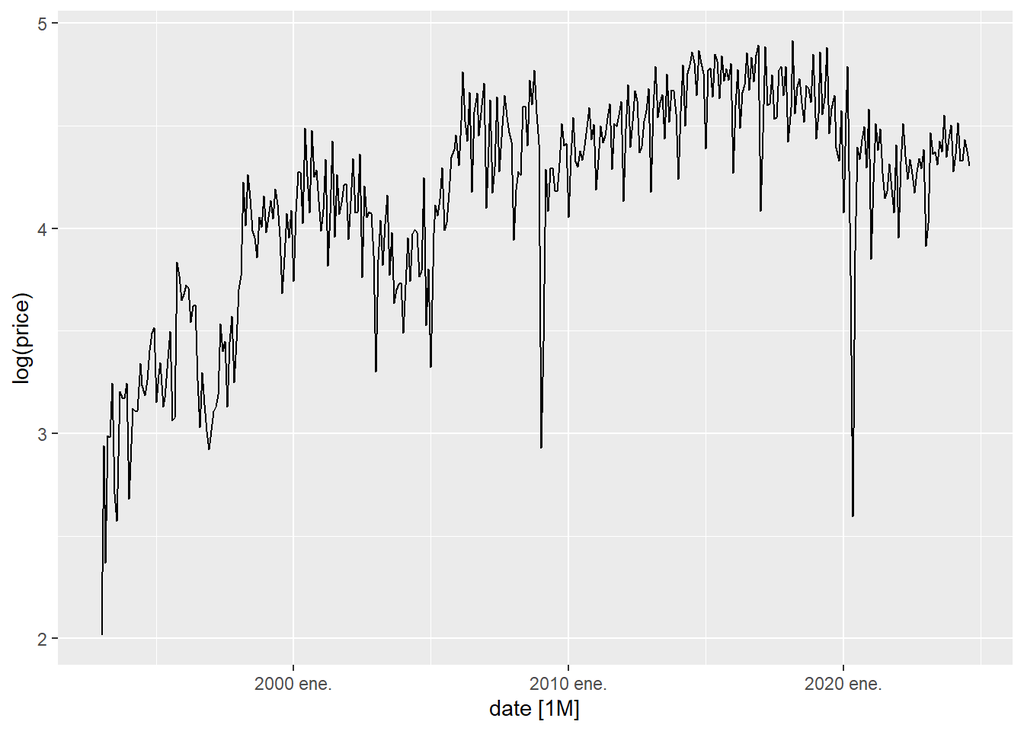

```r
df_train |>
    autoplot(log(price))
```

Descomponemos la serie y lo ploteamos:

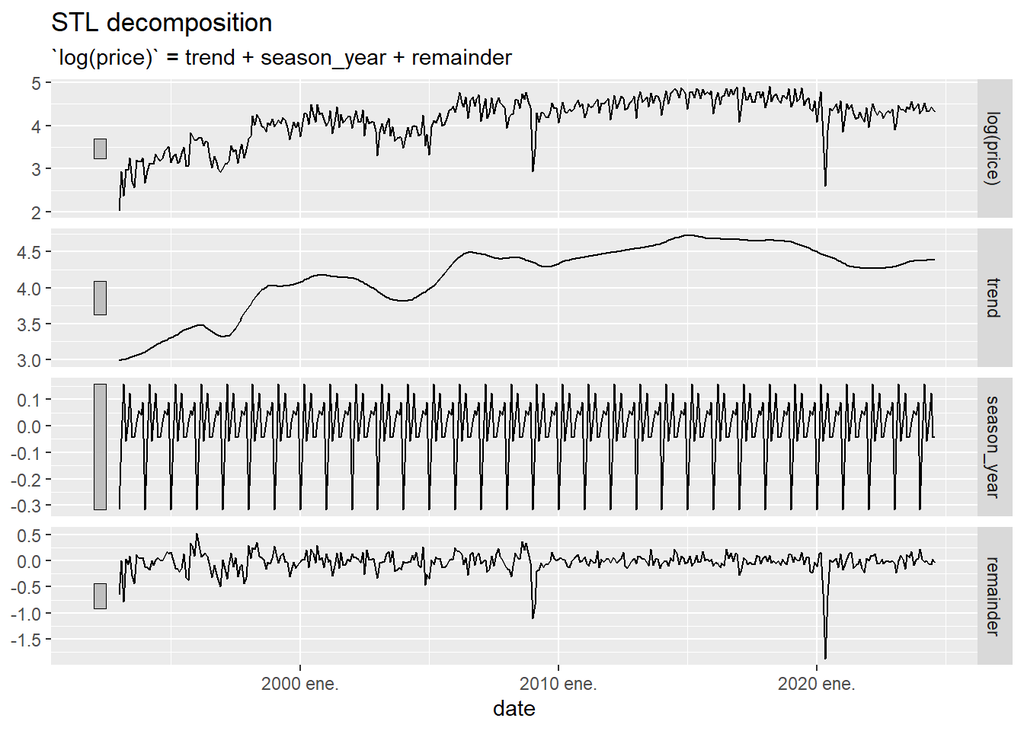

```r
componentes_train <- df_train |>
    model(
        stl = STL(
            log(price) ~ trend(window = 25) + season(window = 'periodic'),
            robust = TRUE
        )
    ) |>
        components()

componentes_train |>
    autoplot()
```

Armamos los modelos y ploteamos residuos de cada uno:

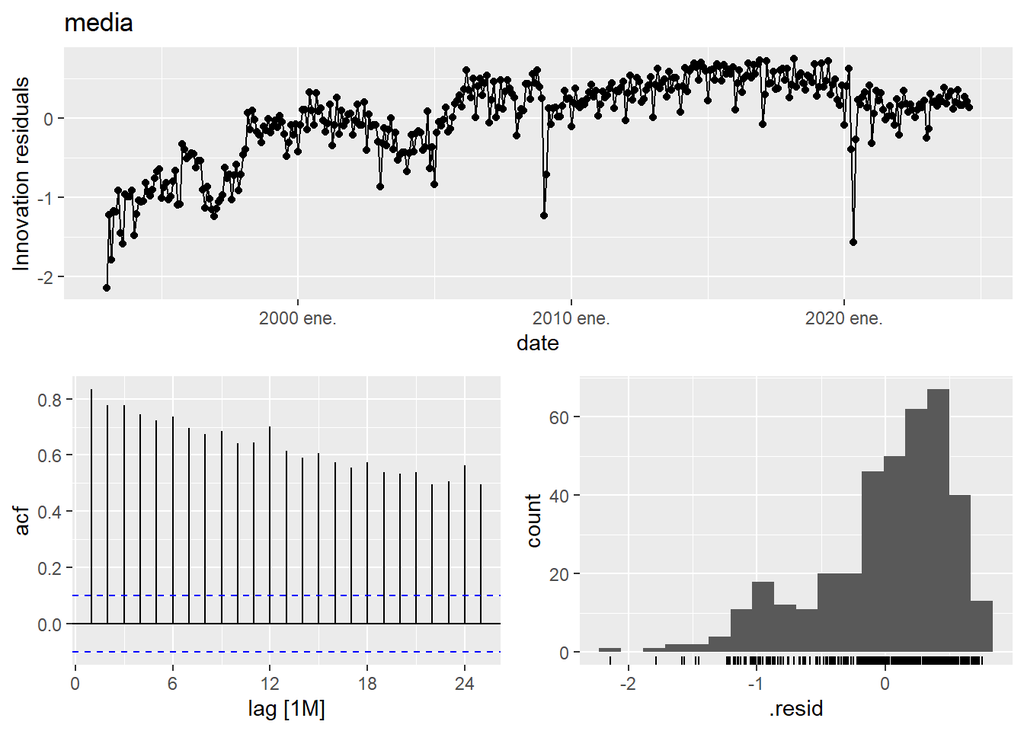

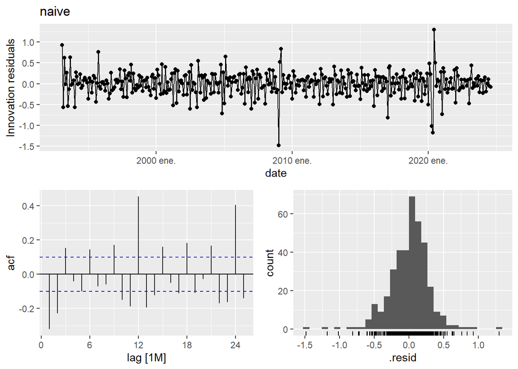

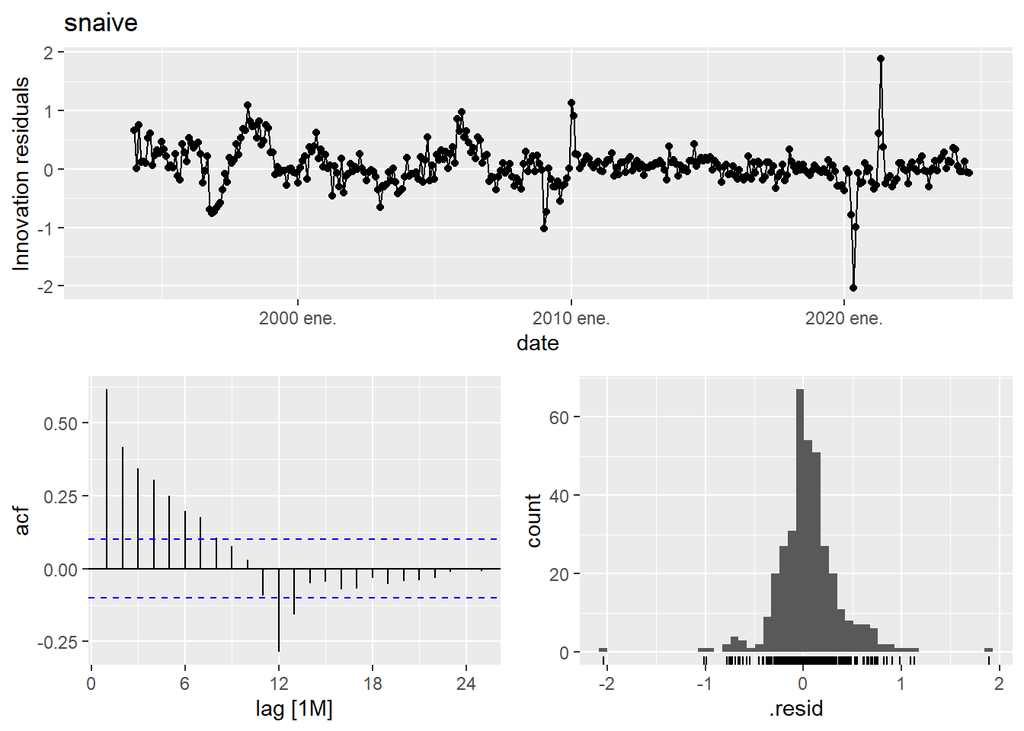

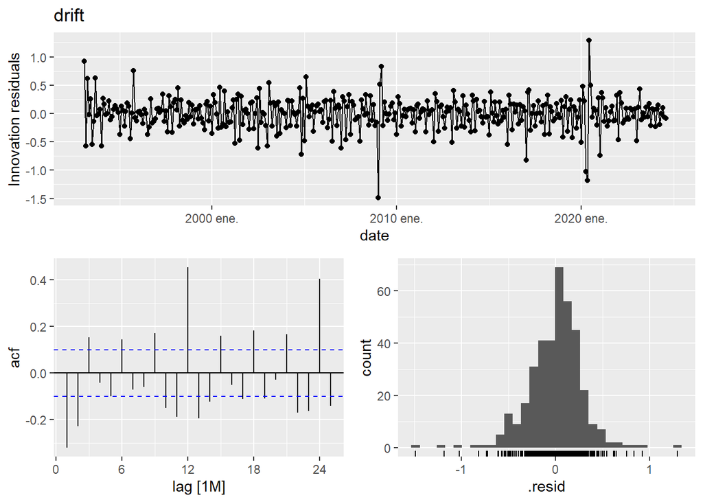

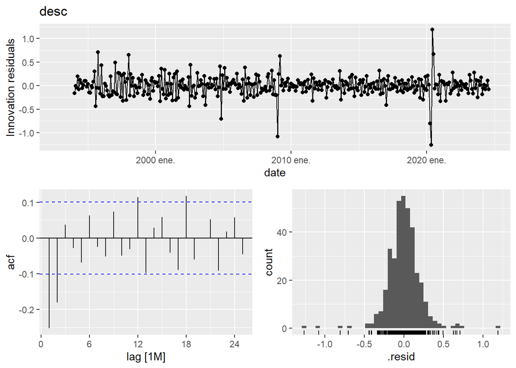

```r
descomposition_log <- decomposition_model(
    STL(
        log(price) ~ trend(window = 25) + season(window = "periodic"),
        robust = TRUE
    ),
    RW(season_adjust ~ drift()),
    SNAIVE(season_year)
)

df_fit <- df_train |>
    model(
        media = MEAN(log(price)),
        naive = NAIVE(log(price)),
        snaive = SNAIVE(log(price)),
        drift = RW(log(price) ~ drift()),
        desc = descomposition_log
    )

for (model in colnames(df_fit)) {
    residuos <- df_fit |>
        select(all_of(model)) |>
        gg_tsresiduals() + labs(title = model)

    print(residuos)
}
```

Test de Ljung-Box con la transformación:

```r
df_fit |>
    augment() |>
    features(.innov, ljung_box, lag = 24)
```

```
# A tibble: 5 × 3
  .model lb_stat  lb_pvalue
  <chr>    <dbl>      <dbl>
1 desc      71.3 0.00000137
2 drift    355.  0
3 media   3927.  0
4 naive    355.  0
5 snaive   395.  0
```

Ahora, hacemos el pronóstico y evaluamos:

```r
df_fc <- df_fit |>
    forecast(h = nrow(df_test))

df_fc |>
  accuracy(df_test)
```

```
# A tibble: 5 × 10
  .model .type    ME  RMSE   MAE   MPE  MAPE  MASE RMSSE   ACF1
  <chr>  <chr> <dbl> <dbl> <dbl> <dbl> <dbl> <dbl> <dbl>  <dbl>
1 desc   Test   7.89  16.5  12.7  5.92  12.4   NaN   NaN  0.104
2 drift  Test   3.03  14.3  11.2  1.38  11.4   NaN   NaN -0.152
3 media  Test  31.7   36.5  32.0 27.9   28.4   NaN   NaN  0.173
4 naive  Test   8.48  16.0  13.1  6.36  12.7   NaN   NaN -0.242
5 snaive Test  17.3   25.9  21.7 13.8   19.4   NaN   NaN  0.128
```

Después, graficamos para ver como es nuestro pronóstico en comparación con los datos de test:

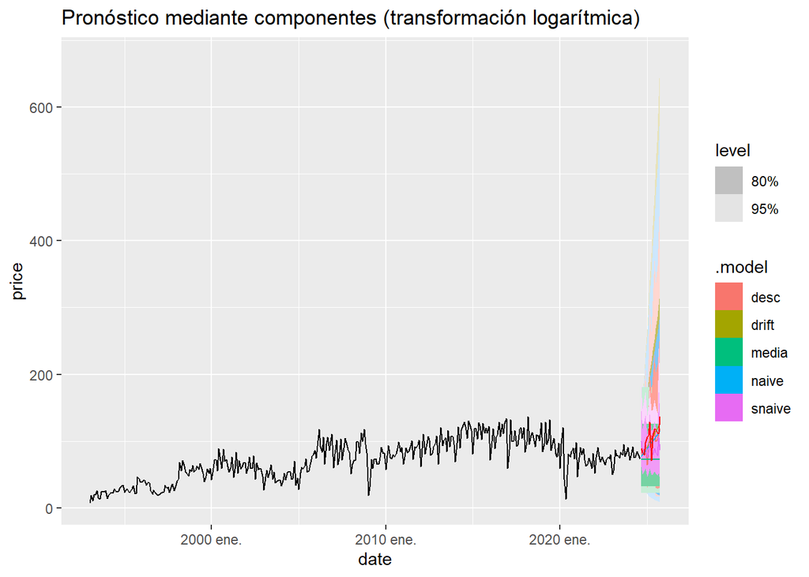

```r
df_fc |>
    autoplot(df_train) +
    autolayer(
        df_test,
        price,
        colour = 'red'
    ) + labs(title = 'Pronóstico mediante componentes (transformación logarítmica)')
```

Con la transformación:

- El error del modelo de descomposición se reduce aproximadamente a la mitad (RMSE y MAPE) frente a la versión en niveles, y la autocorrelación de sus residuos en el rezago 1 baja de forma notable.
- Los modelos `drift` y `naive` obtienen un RMSE puntual algo menor que `desc` en esta ventana de test, pero no son modelos válidos para esta serie: al ignorar la estacionalidad, dejan una autocorrelación enorme en los rezagos 12 y 24, y sus intervalos de predicción, al revertir el logaritmo, se disparan a valores no creíbles a 14 meses.
- Entre los modelos que sí capturan la estacionalidad, el de descomposición sobre `log(price)` es el de menor error y con residuos más cercanos a ruido blanco (aunque, como muestra el test de Ljung-Box, todavía no del todo).

Por lo anterior, seleccionamos el modelo de descomposición STL sobre `log(price)` para el pronóstico final.

## Pronóstico final

```r
df_fit_final <- imports |>
    model(
        combinado = decomposition_model(
            STL(
                log(price) ~ trend(window = 25) + season(window = 'periodic'),
                robust = TRUE
        ),
        RW(trend ~ drift()),
        SNAIVE(season_year),
        MEAN(remainder)
    )
  )
```

```r
df_fc_final <- df_fit_final |>
    forecast(h = 14)
```

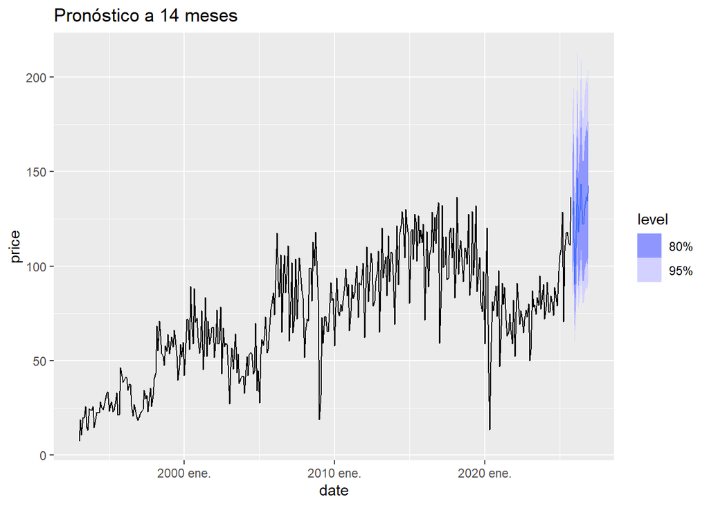

```r
df_fc_final |>
    autoplot(
        imports,
        level = c(80, 95)
    ) +
    labs(
        title = 'Pronóstico a 14 meses'
    )
```

## Conclusiones

**Modelo elegido**

**Diagnóstico de residuos**

Aun con la transformación, los residuos del modelo elegido conservan autocorrelación significativa en los rezagos 1-2 y colas pesadas por los shocks de 2008 y 2020; el test de Ljung-Box rechaza la hipótesis de ruido blanco. Es decir, queda estructura sin capturar: los intervalos de predicción por teoría normal probablemente subestiman la incertidumbre y sería preferible complementarlos con intervalos *bootstrap*.

**Lectura del pronóstico**

El pronóstico a diciembre de 2026 proyecta la continuidad del patrón estacional mensual sobre un nivel en torno al observado recientemente, con un intervalo del 95% amplio y asimétrico. La proyección extrapola el fuerte repunte del cierre de la muestra, por lo que es sensible a ese último tramo: si el repunte fue transitorio, el pronóstico queda sesgado al alza.